# ECON 487 HW4

Tiffany Tian

10/24/2021

```r
library(ggplot2)
library(plyr)
library(dplyr)
library(reshape2)

oj <- read.csv("oj.csv")
```

### 1.a-c

```r
lagged <- oj[c("store", "brand", "week", "price")]
lagged$week <- lagged$week + 1
oj_lagged <- merge(oj, lagged, by = c("brand", "store", "week"))
oj_lagged %<>%
  rename("price" = "price.x", "lagged_price" = "price.y") %>%
  relocate(lagged_price, .after = price) %>%
  select(-c(SSTRDIST, SSTRVOL, CPDIST5, CPWVOL5))

folds <- 5
# Randomized the entire data set
oj_lagged <- oj_lagged[sample(nrow(oj_lagged)),]
# Split the data set into 5 groups
oj_lagged$order <- seq(1, nrow(oj_lagged))
oj_lagged$group <- oj_lagged$order %% folds
# Initialize list to store MSEs
MSE_list <- c()

for (i in 0:(folds - 1)) {
  # Select testing set
  oj_test <- oj_lagged[which(oj_lagged$group == i),]
  # The rest is used as training set
  oj_train <- anti_join(oj_lagged, oj_test)
  model <- lm(logmove ~ log(price) + feat + brand + brand*log(price) +
                log(lagged_price) + AGE60 + EDUC + ETHNIC + INCOME + HHLARGE +
                WORKWOM + HVAL150 + EDUC*log(price) + HHLARGE*log(price),
              data = oj_train)
  oj_test$logmove_hat <- predict(model, newdata=oj_test)
  MSE_list[i + 1] <- mean((oj_test$logmove_hat - oj_test$logmove)^2)
}
MSE_list
```

```
## [1] 0.4055882 0.4411660 0.4472884 0.4121617 0.4405599
```

```r
mean(MSE_list)
```

```
## [1] 0.4293528
```

*The cross validated MSE for each OLS model is as follow 0.4055882, 0.441166, 0.4472884, 0.4121617, 0.4405599, and the mean MSE is 0.4293528.*

### 2.a

```r
library(glmnet)
```

### 2.b & c

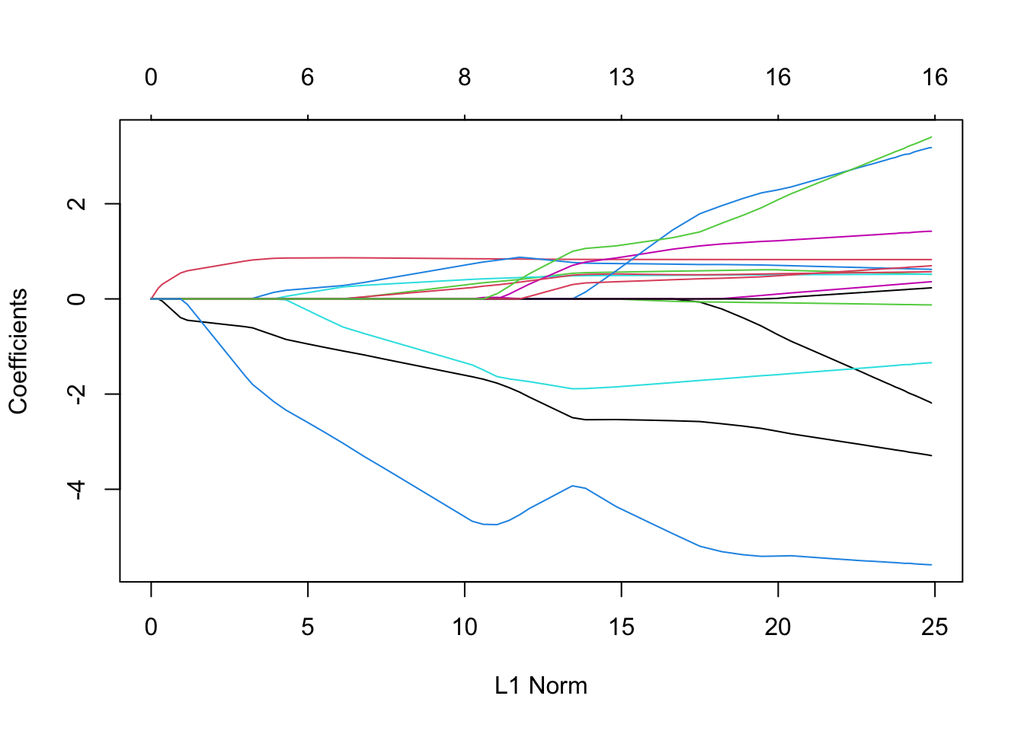

```r
x <- model.matrix(~ log(price) + feat + brand + brand*log(price) +
                log(lagged_price) + AGE60 + EDUC + ETHNIC + INCOME + HHLARGE +
                WORKWOM + HVAL150 + EDUC*log(price) + HHLARGE*log(price),
              data = oj_lagged)
y <- as.numeric(as.matrix(oj_lagged$logmove))
set.seed(720)
lasso_v1 <- glmnet(x, y, alpha=1)
plot(lasso_v1)
```

```r
coef(lasso_v1, s=lasso_v1$lambda.min)
```

```
## 18 x 77 sparse Matrix of class "dgCMatrix"
```

```
##    [[ suppressing 77 column names 's0', 's1', 's2' ... ]]
```

[output not shown]

[output cut: 306 more lines]

```
## feat                         0.8267212  0.8267191  0.8267245  0.8267401
## brandminute.maid             0.5192590  0.5182790  0.5171865  0.5165130
## brandtropicana               0.6237612  0.6227660  0.6211053  0.6198279
## log(lagged_price)            0.5198900  0.5200222  0.5201758  0.5202975
## AGE60                        1.4197011  1.4217426  1.4217679  1.4215511
## EDUC                        -2.1463581 -2.1615311 -2.1767961 -2.1856299
## ETHNIC                       0.5694825  0.5699388  0.5706838  0.5711863
## INCOME                      -0.1251338 -0.1255789 -0.1254847 -0.1254080
## HHLARGE                      3.1657517  3.1751064  3.1788210  3.1798473
## WORKWOM                     -1.3450803 -1.3424925 -1.3419376 -1.3421343
## HVAL150                      0.3555201  0.3582284  0.3602868  0.3616128
## log(price):brandminute.maid  0.2271597  0.2294811  0.2319486  0.2336639
## log(price):brandtropicana    0.6905649  0.6929055  0.6958932  0.6981962
## log(price):EDUC              3.3660501  3.3800267  3.3943479  3.4026746
## log(price):HHLARGE          -5.5840977 -5.5861805 -5.5868068 -5.5863503
```

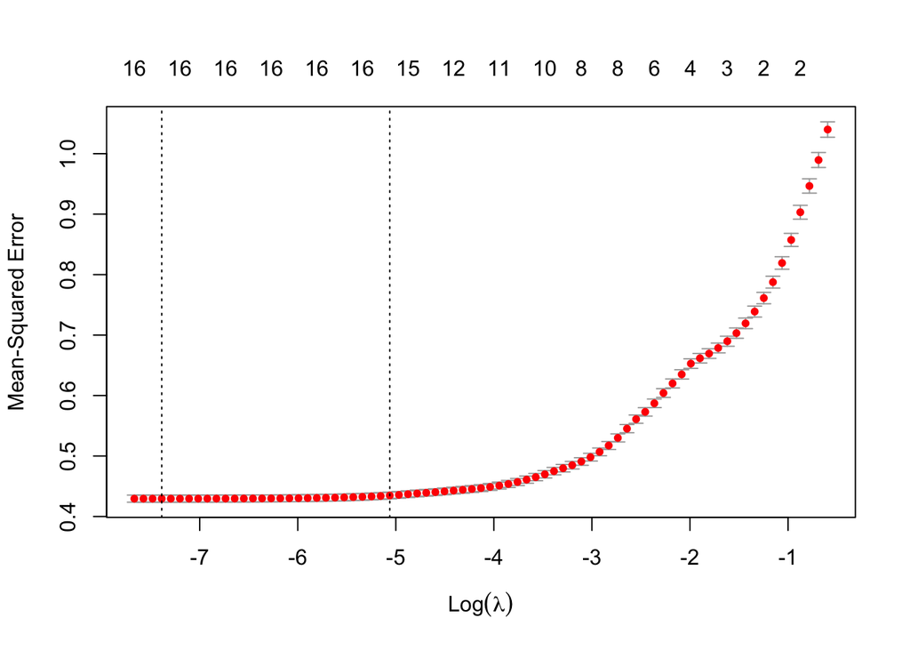

```r
cvfit <- cv.glmnet(x, y, alpha=1)
#Results
plot(cvfit)
```

```r
cvfit$lambda.min
```

```
## [1] 0.000619001
```

```r
log(cvfit$lambda.min)
```

```
## [1] -7.387404
```

```r
coef(cvfit, s = "lambda.min")
```

```
## 18 x 1 sparse Matrix of class "dgCMatrix"
##                                     s1
## (Intercept)                 11.8393721
## (Intercept)                  .
## log(price)                  -3.2778605
## feat                         0.8267212
## brandminute.maid             0.5192590
## brandtropicana               0.6237612
## log(lagged_price)            0.5198900
## AGE60                        1.4197011
## EDUC                        -2.1463581
## ETHNIC                       0.5694825
## INCOME                      -0.1251338
## HHLARGE                      3.1657517
## WORKWOM                     -1.3450803
## HVAL150                      0.3555201
## log(price):brandminute.maid  0.2271597
## log(price):brandtropicana    0.6905649
## log(price):EDUC              3.3660501
## log(price):HHLARGE          -5.5840977
```

Which are the parameters the cross validated LASSO model kicks out of the model?

*The LASSO model included all the parameters.*

What is the ratio of number of features to number of observations?

How might that relate to overfitting from “sampling error”?

*This mean that this model is not overfitting.*

### 2.d

Can you look that the glmnet objects and figure out what the out of sample (e.g., test set) average MSE was with the cross validated LASSO model relative to the model in 1.c?

### 2.e

What is the advantage of using LASSO for choosing model complexity as opposed to using your intuition as an economist?  
i. In what part of this process did you use your intuition as an economist? (HINT: what’s in the X matrix?)

*The advantage of using LASSO is that you can clearly see data supporting which parameters to choose, instead of trying to make an educated guess as an economist. It was only in the part of deciding what parameters to put in as the model when we need to use economic intuition.*

### 3.a

```r
regression <- glm(logmove ~ feat + price + brand + lagged_price + AGE60 + EDUC +
                   ETHNIC + INCOME+ HHLARGE + WORKWOM + HVAL150,
                 data = oj_lagged)
summary(regression)
```

```
##
## Call:
## glm(formula = logmove ~ feat + price + brand + lagged_price +
##     AGE60 + EDUC + ETHNIC + INCOME + HHLARGE + WORKWOM + HVAL150,
##     data = oj_lagged)
##
## Deviance Residuals:
##     Min       1Q   Median       3Q      Max
## -4.6709  -0.4285  -0.0020   0.4225   3.0154
##
## Coefficients:
##                  Estimate Std. Error  t value Pr(>|t|)
## (Intercept)      12.42987    0.33038   37.623  < 2e-16 ***
## feat              0.84881    0.01091   77.818  < 2e-16 ***
## price            -1.22340    0.01095 -111.764  < 2e-16 ***
## brandminute.maid  0.50570    0.01176   43.018  < 2e-16 ***
## brandtropicana    1.12660    0.01644   68.528  < 2e-16 ***
## lagged_price      0.22823    0.01038   21.989  < 2e-16 ***
## AGE60             1.49432    0.13335   11.206  < 2e-16 ***
## EDUC              0.54230    0.10532    5.149 2.64e-07 ***
## ETHNIC            0.56336    0.03799   14.829  < 2e-16 ***
## INCOME           -0.16022    0.03303   -4.851 1.23e-06 ***
## HHLARGE          -1.16700    0.24576   -4.749 2.06e-06 ***
## WORKWOM          -1.39181    0.15033   -9.258  < 2e-16 ***
## HVAL150           0.39131    0.04239    9.232  < 2e-16 ***
## ---
## Signif. codes:  0 '***' 0.001 '**' 0.01 '*' 0.05 '.' 0.1 ' ' 1
##
## (Dispersion parameter for gaussian family taken to be 0.4863446)
##
##     Null deviance: 29152  on 28007  degrees of freedom
## Residual deviance: 13615  on 27995  degrees of freedom
## AIC: 59309
##
## Number of Fisher Scoring iterations: 2
```

*i. The predicted elasticity for Dominick’s when the lagged price is $1 would be 12.65.* *I didn’t interact lagged price with current period price because lagged price impact the log move this period, but not the elasticity.*

*ii. For Tropicana, the predicted elasticity is 13.56.*

*iii. For Tropicana when it’s featured, the predicted elasticity is 14.41.*

### 3.b

*Dominick’s have the most elastic demand, it should have the lowest markup over costs because its customer are very price-sensitive and they’d want to keep the price as close to the cost as possible.*

### 4.a

```r
oj_prices <-oj[,1:6]
oj_wide <- dcast(oj_prices, store + week ~ brand)
colnames(oj_wide)[3] <- "P_Dom"
colnames(oj_wide)[4] <- "P_MM"
colnames(oj_wide)[5] <- "P_Trop"
oj_cross <- merge(oj, oj_wide, by=c("week","store"))

trop <- glm(logmove ~ log(price) + AGE60 + EDUC + ETHNIC + INCOME + HHLARGE +
              WORKWOM + HVAL150 + log(P_Dom) + log(P_MM) + log(P_Trop),
            data = oj_cross %>% filter(brand == "tropicana"))
mm <- glm(logmove ~ log(price) + AGE60 + EDUC + ETHNIC + INCOME + HHLARGE +
            WORKWOM + HVAL150 + log(P_Dom) + log(P_MM) + log(P_Trop),
          data = oj_cross %>% filter(brand == "minute.maid"))
dom <- glm(logmove ~ log(price) + AGE60 + EDUC + ETHNIC + INCOME + HHLARGE +
             WORKWOM + HVAL150 + log(P_Dom) + log(P_MM) + log(P_Trop),
           data = oj_cross %>% filter(brand == "dominicks"))

rownames = c("Q Tropicana", "Q Minute Maid", "Q Dominick's")
colnames = c("P Tropicana", "P Minute Maid", "P Dominick's")
elasticities <- matrix(NA, 3, 3, dimnames = list(rownames, colnames))

elasticities[1,1] <- coef(trop)["log(P_Trop)"]
elasticities[1,2] <- coef(trop)["log(P_MM)"]
elasticities[1,3] <- coef(trop)["log(P_Dom)"]
elasticities[2,1] <- coef(mm)["log(P_Trop)"]
elasticities[2,2] <- coef(mm)["log(P_MM)"]
elasticities[2,3] <- coef(mm)["log(P_Dom)"]
elasticities[3,1] <- coef(dom)["log(P_Trop)"]
elasticities[3,2] <- coef(dom)["log(P_MM)"]
elasticities[3,3] <- coef(dom)["log(P_Dom)"]

elasticities
```

```
##               P Tropicana P Minute Maid P Dominick's
## Q Tropicana            NA     0.2773553    0.1745437
## Q Minute Maid 1.098992365            NA    0.8521149
## Q Dominick's  0.003796813     1.1727798           NA
```

### 4.b

```r
trop_feat <- glm(logmove ~ log(price) + AGE60 + EDUC + ETHNIC + INCOME + HHLARGE +
              WORKWOM + HVAL150 + log(P_Dom) + log(P_MM) + log(P_Trop) +
                log(P_Dom)*feat + log(P_MM)*feat + log(P_Trop)*feat,
                 data = oj_cross %>% filter(brand == "tropicana"))
mm_feat <- glm(logmove ~ log(price) + AGE60 + EDUC + ETHNIC + INCOME + HHLARGE +
            WORKWOM + HVAL150 + log(P_Dom) + log(P_MM) + log(P_Trop) +
                log(P_Dom)*feat + log(P_MM)*feat + log(P_Trop)*feat,
          data = oj_cross %>% filter(brand == "minute.maid"))
dom_feat <- glm(logmove ~ log(price) + AGE60 + EDUC + ETHNIC + INCOME + HHLARGE +
             WORKWOM + HVAL150 + log(P_Dom) + log(P_MM) + log(P_Trop) +
                log(P_Dom)*feat + log(P_MM)*feat + log(P_Trop)*feat,
           data = oj_cross %>% filter(brand == "dominicks"))

elasticities_feat <- matrix(NA, 3, 3, dimnames = list(rownames, colnames))

elasticities_feat[1,1] <- coef(trop_feat)["log(P_Trop)"]
elasticities_feat[1,2] <- coef(trop_feat)["log(P_MM)"]
elasticities_feat[1,3] <- coef(trop_feat)["log(P_Dom)"]
elasticities_feat[2,1] <- coef(mm_feat)["log(P_Trop)"]
elasticities_feat[2,2] <- coef(mm_feat)["log(P_MM)"]
elasticities_feat[2,3] <- coef(mm_feat)["log(P_Dom)"]
elasticities_feat[3,1] <- coef(dom_feat)["log(P_Trop)"]
elasticities_feat[3,2] <- coef(dom_feat)["log(P_MM)"]
elasticities_feat[3,3] <- coef(dom_feat)["log(P_Dom)"]

elasticities_feat
```

```
##               P Tropicana P Minute Maid P Dominick's
## Q Tropicana            NA     0.1457653    0.0868439
## Q Minute Maid   0.2935401            NA    0.5255279
## Q Dominick's   -0.2859929     0.8087495           NA
```

*i. The estimates became smaller across all coefficients.*

*ii. Dominick’s suffer the most when Minute Maid is featured and lowers its price.*

### 4.c

Minute Maid and Dominick’s are the most competitive with each other.

*i. We can tell from the magnitude of cross-price elasticity that the sales of Minute Maid and Dominick’s are being the most impacted by each other’s price.*

*ii. The correlation of prices for those two products would be more correlated because of how much their prices impact each other.*

### 4.d

```r
oj_prices_lagged <-oj_lagged[,1:7]
oj_wide_lagged <- dcast(oj_prices_lagged, store + week ~ brand)
colnames(oj_wide_lagged)[3] <- "P_Dom"
colnames(oj_wide_lagged)[4] <- "P_MM"
colnames(oj_wide_lagged)[5] <- "P_Trop"
oj_cross_lagged <- merge(oj_lagged, oj_wide_lagged, by=c("week","store"))
trop_comp <- glm(logmove ~ log(price) + log(P_Dom) + log(P_MM) + log(P_Trop) +
                   log(P_Dom)*feat + log(P_MM)*feat + log(P_Trop)*feat +
                   lagged_price + P_Dom + P_MM + P_Trop,
                 data = oj_cross_lagged %>% filter(brand == "tropicana"))
mm_comp <- glm(logmove ~ log(price) + log(P_Dom) + log(P_MM) + log(P_Trop) +
                 log(P_Dom)*feat + log(P_MM)*feat + log(P_Trop)*feat +
                 lagged_price + P_Dom + P_MM + P_Trop,
          data = oj_cross_lagged %>% filter(brand == "minute.maid"))
dom_comp <- glm(logmove ~ log(price) + log(P_Dom) + log(P_MM) + log(P_Trop) +
                  log(P_Dom)*feat + log(P_MM)*feat + log(P_Trop)*feat +
                  lagged_price + P_Dom + P_MM + P_Trop,
           data = oj_cross_lagged %>% filter(brand == "dominicks"))

elasticities_comp <- matrix(NA, 3, 3, dimnames = list(rownames, colnames))

elasticities_comp[1,1] <- coef(trop_comp)["log(P_Trop)"]
elasticities_comp[1,2] <- coef(trop_comp)["log(P_MM)"]
elasticities_comp[1,3] <- coef(trop_comp)["log(P_Dom)"]
elasticities_comp[2,1] <- coef(mm_comp)["log(P_Trop)"]
elasticities_comp[2,2] <- coef(mm_comp)["log(P_MM)"]
elasticities_comp[2,3] <- coef(mm_comp)["log(P_Dom)"]
elasticities_comp[3,1] <- coef(dom_comp)["log(P_Trop)"]
elasticities_comp[3,2] <- coef(dom_comp)["log(P_MM)"]
elasticities_comp[3,3] <- coef(dom_comp)["log(P_Dom)"]

elasticities_comp
```

```
##               P Tropicana P Minute Maid P Dominick's
## Q Tropicana     -4.114182     0.1891368   -0.5335507
## Q Minute Maid   -1.633628    -0.1437552   -2.0468643
## Q Dominick's     2.007973    -1.2759753    2.9090898
```